# Assignment 3 Task 3

Sarah Lam

10/23/2021

```r
knitr::opts_chunk$set(echo = TRUE, messages = FALSE, warning = FALSE)

library(tidyverse)
library(here)
library(janitor)
library(kableExtra)
library(lubridate)
```

# Overview

This code practices version control, data wrangling, and analysis & visualization skills to explore data about red and purple urchins from the Santa Barbara area collected by the Santa Barbara Coastal Long Term Ecological Research program divers.

Data: Reed, D. 2020. SBC LTER: Reef: Long-term experiment: Kelp removal: Urchin size frequency distribution ver 20. Environmental Data Initiative. https://doi.org/10.6073/pasta/5a1e9ef03aa47bd2225c0bb98a02a63b.

# Read in the Data

```r
urchins <- read_csv(here("data", "urchins.csv")) %>% # read in data and clean names in same line
  clean_names()
```

# Section 1: Size Comparison of Red and Purple Urchins

## Data Visualization

This code compares the diameters(cm) of purple and red urchins in a faceted histogram using ggplot::geom_histogram() and facet_wrap() to divide the plot by urchin common name.

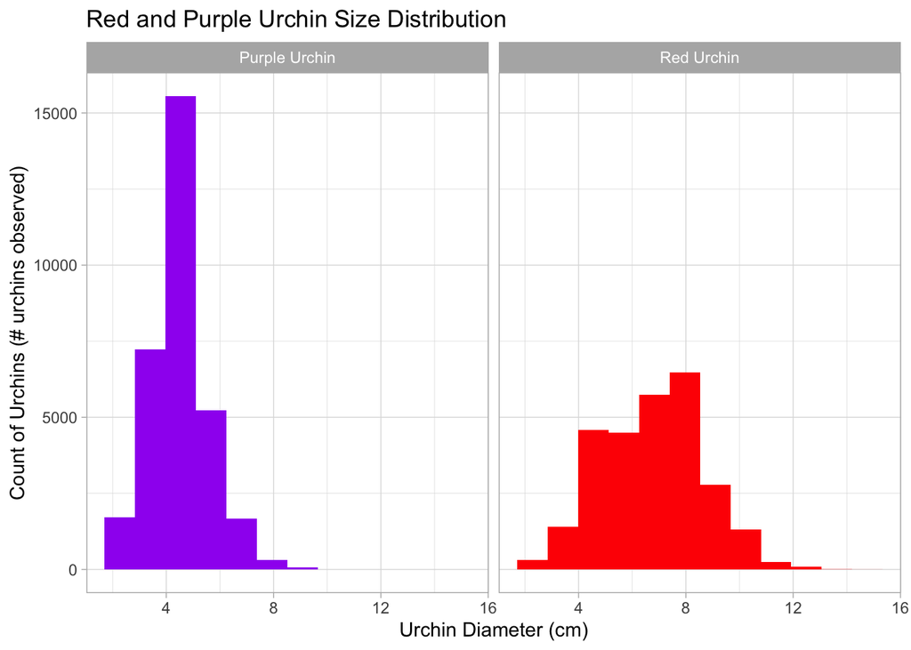

This histogram shows the size distributions of purple and red urchins (diameter, cm). The purple urchins, shown in purple, have a normal looking distribution with a mean around 4.5cm. The red urchins, shown in red, also have a normal looking distribution but a shorter, wider curve, the mean apprear to be around 7cm.

```r
ggplot(data = urchins, aes(x = size)) +
  geom_histogram(bins = 12,
                 aes(fill = common_name),
                 show.legend = FALSE) +
  facet_wrap(~common_name) +
  scale_fill_manual(values = c("Purple Urchin" = "purple",
                               "Red Urchin" = "red")) +
  theme_light() +
  labs(x = "Urchin Diameter (cm)",
       y = "Count of Urchins (# urchins observed)",
       title = "Red and Purple Urchin Size Distribution")
```

## Descriptive Statistics Table

This code first summarizes and then creates a table of the summary statistics mean, median, standard deviation, and sample size for purple and red urchins, using kableExtra::kable() to finalize the table in the knitted document.

```r
urchins_size_summary <- urchins %>%
  group_by(common_name) %>%
  summarize(mean = round(mean(size, na.rm = TRUE), 1),
            median = median(size, na.rm = TRUE),
            standard_deviation = round(sd(size, na.rm = TRUE), 1),
            sample_size = n())

urchins_size_summary %>%
  kable(col.names = c("Species",
                      "Mean Diameter (cm)",
                      "Median Diameter (cm)",
                      "Standard Deviation",
                      "Sample Size (n)"),
        caption = "This table shows a summary of the mean urchin diameter (cm), median urchin diameter (cm), the sandard deviation, and the sample size for pruple and red urchins.") %>%
  kable_styling(full_width = FALSE)
```

This table shows a summary of the mean urchin diameter (cm), median urchin diameter (cm), the sandard deviation, and the sample size for pruple and red urchins.

| Species | Mean Diameter (cm) | Median Diameter (cm) | Standard Deviation | Sample Size (n) |
| --- | --- | --- | --- | --- |
| Purple Urchin | 4.5 | 4.5 | 1.2 | 31805 |
| Red Urchin | 6.8 | 7.0 | 1.9 | 27408 |

# Section 2. Purple Urchin Counts By Site and Year

This code first create a subset of data called “purple_urchins” that only keeps purple urchin and changes the date column format and class to make the year a more usable variable. It then groups by site and year in order to visualize the data as the observes urchins at each site each year.

```r
purple_urchins <- urchins %>%
  filter(common_name == "Purple Urchin") %>%
  mutate(date_class = mdy(date)) %>%
  mutate(year = year(date_class)) %>%
  mutate(site_full = case_when(     # case_when() form of if/else statement telling it if x==y, then (~) xyz
    site == "NAPL" ~ "Naples Reef",
    site == "AQUE" ~ "Arroyo Quemado Reef",
    site == "CARP" ~ "Carpinteria Reef",
    site == "MOHK" ~ "Mohawk Reef",
    site == "IVEE" ~ "Isla Vista Reef"
  ))

site_by_year <- purple_urchins %>%
  group_by(site_full, year) %>%
  summarize(count = n())
```

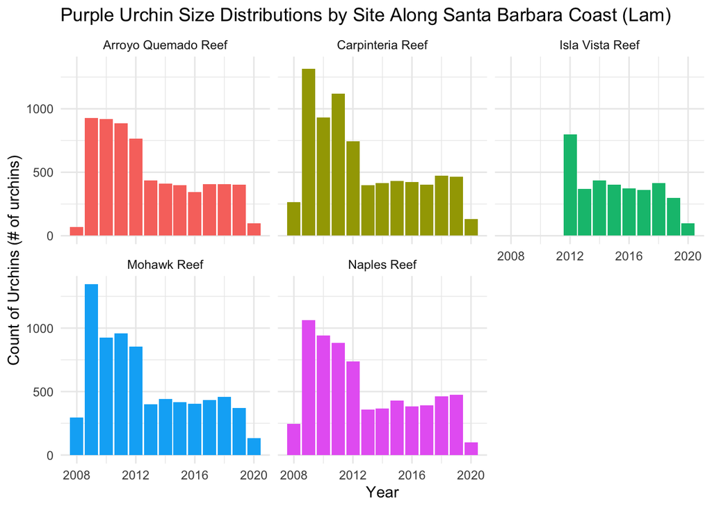

This figure shows the number of purple urchins observed from 2008 to 2020 at five sites along the Santa Barbara coast. All of the sites appear to show varying degrees of a downward trend in count size. While the sites show a higher variety of number of urchins around 2008 to 2012, the site counts appear more similar from 2012 to 2020.

```r
ggplot(data = site_by_year, aes(x = year, y = count)) +
  geom_col(aes(fill = site_full),
           show.legend = FALSE) +
  facet_wrap(~site_full) +
  theme_minimal() +
  labs(x = "Year",
       y = "Count of Urchins (# of urchins)",
       title = "Purple Urchin Size Distributions by Site Along Santa Barbara Coast (Lam)")
```

### Analysis

I think that this graph may not accurately reflect the changes in the purple urchin population. First of all, we ignored the treatment variable for this graph which could be skewing the overall populations lower as we see here, but the control group might not have such a drastic population decrease. Additionally, data collection methods could explain some of the changes that we see in number of purple urchins observed. For example, four of the sites start with very low populations in 2008 and then drastically jump to a higher number the next year, it seems unlikely that there would be that quick of a spike in urchin populations and more likely that the data collection effort changed in such a way that data collection became better in the second year. Similarly, the Isla Vista Reef has no urchin observed until 2012, again it seems more like that the site was simply added to the data collection effort later than the other rather than the urchins suddenly appearing there. Finally, the sudden drop off in urchin population across sites in 2020 could be linked to the COVID-19 pandemic and decreased data collection efforts or ability due to new rules and regulations. In order to determine whether the changes in counts by year are reflective of actual changes in urchin population we would need to take these factors into account and determine the significance of their impact.